# Лабораторная работа № 6

Модель распространения рекламы

Анна Светцова

1132230807@pfur.ru

Российский университет дружбы народов

2026-10-08

# Информация

## Докладчик

**Анна Светцова**

Российский университет дружбы народов

1132230807@pfur.ru

# Вводная часть

## Актуальность

- Реклама распространяется как напрямую, так и через уже информированных потребителей
- Скорость роста аудитории зависит от числа информированных и неинформированных людей
- Математическая модель позволяет сравнить разные механизмы распространения информации

## Цель работы

Исследовать модель распространения рекламы для варианта 58:

- построить решения для трёх заданных случаев;
- определить максимальную скорость распространения во втором случае;
- изучить влияние коэффициента сарафанного радио.

# Постановка задачи

## Исходные данные

Для варианта 58:

$$N=761,$$

$$n(0)=6.$$

Здесь $N$ — максимальный объём потенциальной аудитории, а $n(t)$ — число уже информированных потребителей.

## Общая модель

$$\frac{dn}{dt}
=
\left(\alpha_1(t)+\alpha_2(t)n(t)\right)
\left(N-n(t)\right).$$

$\alpha_1$ характеризует прямую рекламу, а $\alpha_2n$ — распространение информации через уже информированных потребителей.

# Математические модели

## Первый случай

$$\frac{dn}{dt}
=
(0.82+0.00003n)(N-n).$$

Основной вклад даёт непосредственная рекламная кампания.

## Второй случай

$$\frac{dn}{dt}
=
(0.00003+0.82n)(N-n).$$

Основной вклад создаёт эффект сарафанного радио.

## Третий случай

$$\frac{dn}{dt}
=
(0.2\sin t+0.8\cos(t)n)(N-n).$$

Интенсивности распространения дополнительно изменяются во времени.

# Основной эксперимент

## Первый случай

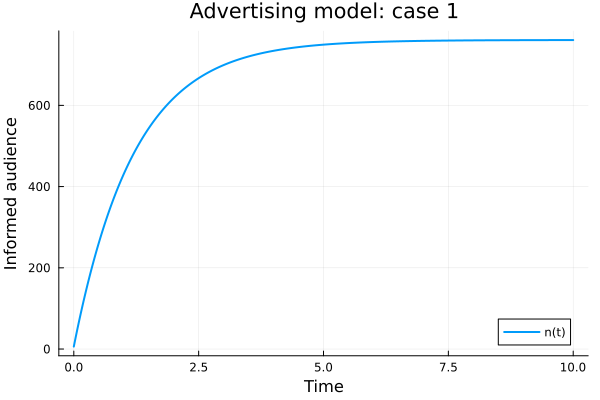

Аудитория быстро увеличивается и постепенно приближается к максимально возможному значению.

## Второй случай

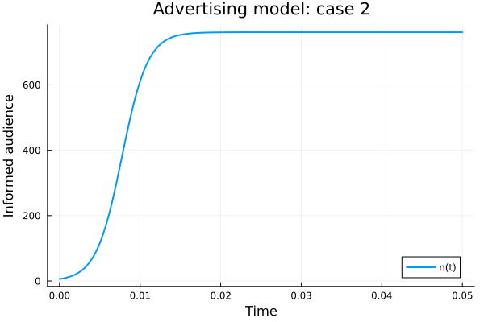

Рост сначала ускоряется благодаря увеличению числа информированных потребителей, а затем замедляется из-за насыщения аудитории.

## Максимальная скорость

Во втором случае

$$v(n)=(a+bn)(N-n),$$

где

$$a=0.00003,\qquad b=0.82.$$

Максимум достигается при

$$n_*\approx380.5.$$

## Момент максимальной скорости

Для варианта 58:

$$t_*\approx0.00775,$$

а максимальная скорость составляет приблизительно

$$\left(\frac{dn}{dt}\right)_{\max}
\approx118720.$$

## График скорости

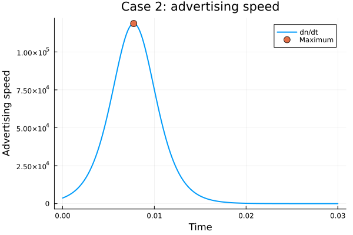

Максимальная скорость достигается примерно при охвате половины потенциальной аудитории.

## Третий случай

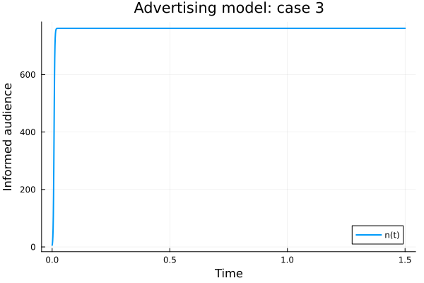

# Параметрическое исследование

## Изменяемый параметр

Рассматривается модель

$$\frac{dn}{dt}
=
(a+bn)(N-n),$$

где

$$a=0.00003$$

и

$$b\in\{0.4,\;0.82,\;1.2\}.$$

## Результат исследования

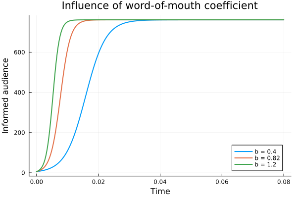

Чем больше коэффициент сарафанного радио, тем быстрее аудитория достигает насыщения.

## Численные результаты

| $b$ | Максимальная скорость | Время максимума |
| --- | --- | --- |
| 0.40 | 57912 | 0.01588 |
| 0.82 | 118720 | 0.00775 |
| 1.20 | 173736 | 0.00529 |

С увеличением $b$ максимум скорости становится выше и наступает раньше.

# Воспроизводимость

## Организация вычислений

- реализация выполнена на Julia;
- задачи решены с помощью `DifferentialEquations.jl`;
- использован метод `Tsit5`;
- результаты сохранены в CSV;
- построены графики PNG;
- сформированы Jupyter Notebook и Quarto-документация.

# Результаты

## Основные результаты

- реализованы три модели распространения рекламы;
- построены графики изменения числа информированных;
- найден момент максимальной скорости второго случая;
- исследовано влияние коэффициента сарафанного радио;
- подтверждена воспроизводимость вычислений.

# Итоги

## Вывод

Во всех трёх моделях число информированных стремится к максимальному объёму аудитории.

Во втором случае доминирует сарафанное радио, и максимальная скорость достигается примерно при охвате половины аудитории.

Рост коэффициента сарафанного радио увеличивает максимальную скорость распространения и приводит к более раннему насыщению аудитории.